# Kaggle Titanic Dataset

Rahul Sangole

Dec 20, 2016

# Objectives

1. End to end analysis using R
2. Learn the caret package for ML
3. Learn to present the case using R Notebooks

# Read in the dataset

I stored the raw files on Github, so I used [RCurl](https://cran.r-project.org/web/packages/RCurl/index.html) with [Wehrley’s method](https://github.com/wehrley/wehrley.github.io/blob/master/SOUPTONUTS.md) that utilizes read.csv to the fullest. It’s one of the best ways I’ve found to read in data and also set data-types at the same time. He’s done a great job on that function. The dataset contains one ID variable, one response variable and ten predictor variables.

```r
library(RCurl,quietly = T)
library(dplyr,quietly = T)
library(ggplot2,quietly = T)
library(gridExtra,quietly = T)
library(Amelia,quietly = T)
library(beanplot,quietly = T)
library(caret,quietly = T)
library(stringr,quietly = T)


readData <- function(path.name, file.name, column.types, missing.types) {
    gurl <- paste(path.name,file.name,sep="")
    download.file(gurl,file.name,method="curl",quiet = T)
    tbl_df(read.csv(file.name,colClasses=column.types,
             na.strings=missing.types))
}

Titanic.path <- "https://raw.githubusercontent.com/rsangole/Titanic/master/"
train.data.file <- "train.csv"
test.data.file <- "test.csv"
missing.types <- c("NA", "")
train.column.types <- c('integer',   # PassengerId
                        'factor',    # Survived
                        'factor',    # Pclass
                        'character', # Name
                        'factor',    # Sex
                        'numeric',   # Age
                        'integer',   # SibSp
                        'integer',   # Parch
                        'character', # Ticket
                        'numeric',   # Fare
                        'character', # Cabin
                        'factor'     # Embarked
)

test.column.types <- train.column.types[-2]     # # no Survived column in test.csv
train.raw <- readData(Titanic.path, train.data.file,train.column.types,missing.types)
test.raw <- readData(Titanic.path, test.data.file,test.column.types,missing.types)
train.raw <- train.raw %>% select(-PassengerId)
test.raw <- test.raw %>% select(-PassengerId)
str(train.raw)
```

```
## Classes 'tbl_df', 'tbl' and 'data.frame':    891 obs. of  11 variables:
##  $ Survived: Factor w/ 2 levels "0","1": 1 2 2 2 1 1 1 1 2 2 ...
##  $ Pclass  : Factor w/ 3 levels "1","2","3": 3 1 3 1 3 3 1 3 3 2 ...
##  $ Name    : chr  "Braund, Mr. Owen Harris" "Cumings, Mrs. John Bradley (Florence Briggs Thayer)" "Heikkinen, Miss. Laina" "Futrelle, Mrs. Jacques Heath (Lily May Peel)" ...
##  $ Sex     : Factor w/ 2 levels "female","male": 2 1 1 1 2 2 2 2 1 1 ...
##  $ Age     : num  22 38 26 35 35 NA 54 2 27 14 ...
##  $ SibSp   : int  1 1 0 1 0 0 0 3 0 1 ...
##  $ Parch   : int  0 0 0 0 0 0 0 1 2 0 ...
##  $ Ticket  : chr  "A/5 21171" "PC 17599" "STON/O2. 3101282" "113803" ...
##  $ Fare    : num  7.25 71.28 7.92 53.1 8.05 ...
##  $ Cabin   : chr  NA "C85" NA "C123" ...
##  $ Embarked: Factor w/ 3 levels "C","Q","S": 3 1 3 3 3 2 3 3 3 1 ...
```

# Missing values analysis

Quick investigation of missing values can be done using the `complete.cases()`, and more thorough graphical summary can be done using Amelia. Overall, 79% of the observations have *some* missing data.

```r
#Complete cases (percentages)
round(prop.table(table(complete.cases(train.raw))),2)
```

```
##
## FALSE  TRUE
##  0.79  0.21
```

Amelia lets us graphically investigate which variables have missing data. `apply()` gives this same information numerically in a succint fashion.

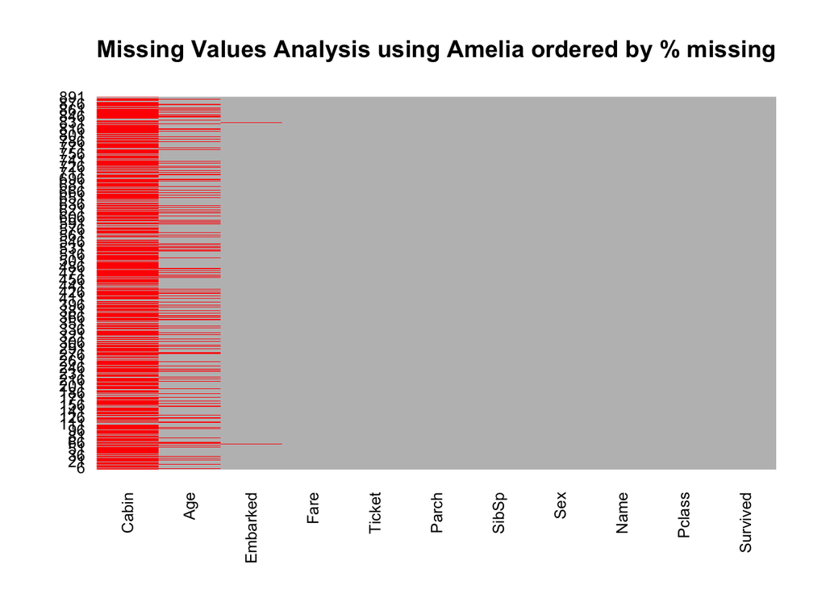

```r
missmap(train.raw, main='Missing Values Analysis using Amelia ordered by % missing', col=c('red', 'gray'),legend = F,rank.order = T)
```

```r
#Missing cases (numbers):
apply(train.raw,MARGIN = 2,FUN = function(x) sum(is.na(x)))
```

```
## Survived   Pclass     Name      Sex      Age    SibSp    Parch   Ticket
##        0        0        0        0      177        0        0        0
##     Fare    Cabin Embarked
##        0      687        2
```

```r
#Missing cases (percentages):
round(apply(train.raw,MARGIN = 2,FUN = function(x) sum(is.na(x))/length(x)),2)
```

```
## Survived   Pclass     Name      Sex      Age    SibSp    Parch   Ticket
##     0.00     0.00     0.00     0.00     0.20     0.00     0.00     0.00
##     Fare    Cabin Embarked
##     0.00     0.77     0.00
```

Cabin has a large number of missing values (77% missing). Imputing this variable may prove challenging or even useless. Age (19.9% missing) and Embarked (0.2%) missing are much more managable.

# EDA

The first step in the analysis is to explore the data numerically and graphically. I always split up my EDA investigation as follows:

- Target Variable
- Predictor Variables
  - Univariate
  - Bivariate
  - Multivariate

This gives me a structured approach towards larger datasets. My [professor](http://www.syamalasrinivasan.com/) at Northwestern taught me to always complete a thorough intimate numeric & graphical EDA on the data, no matter how large the data [^1]. [Anscombe](http://www.jstor.org/stable/2682899) (1973) clearly shows the importance of graphical analyses.

## Target Variable

`Survived` is the response variable. As we can see, a large majority of the passengers did not survive the accident. The response variable is a False/True boolean variable. Thus, the analysis techniques used later will be those appropriate for classification problems.

```r
round(prop.table(table(train.raw$Survived)),2)
```

```
##
##    0    1
## 0.62 0.38
```

## Predictor Variables

### Univariate & Bivariate

The first step is to look at every variable available. I prefer using the `ggplot2` framework for all the visuals.

#### Continuous Variables

- `Age` seems to have a bimodal distribution - very young children, and then directly young adults to mid-age persons. The 2nd mode is right skewed with no obvious outliers.
- `Fare` certainly shows many outliers beyond the ~$200 level. A majority of the fares are <$50, which makes sense since a majority of the travelers are bound to be in the 3rd passenger class.

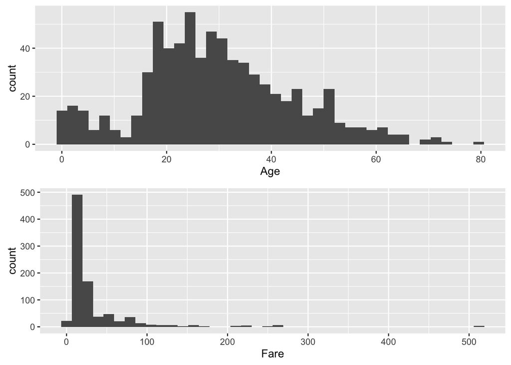

```r
p1 <- ggplot(data=train.raw,aes(x=Age))+geom_histogram(bins = 40)
p2 <- ggplot(data=train.raw,aes(x=Fare))+geom_histogram(bins = 40)
grid.arrange(p1,p2)
```

As we can see, the median fare is $14.5, the mean is $32, but the max is $512. We’ll investigate winzorising this variable in the latter part. Perhaps a transformation will also help?

```r
summary(train.raw$Fare)
```

```
##    Min. 1st Qu.  Median    Mean 3rd Qu.    Max.
##    0.00    7.91   14.45   32.20   31.00  512.30
```

#### Categorical Variables

A ggplot command is iterated over for the categorical variables.[^2]

Key takeways for the categorical variables:

1. `Pclass`: If you were traveling 1st class, you have the highest chance of survival. Could be indicative of preferential treatment to those who paid more, a less politically correct class-stratified society, as well as the fact that the 1st class passengers had cabins at the very top of the ship.
2. `Pclass`: Persons traveling 3rd class had the highest fatality rate. 3rd class passengers had cabins deep in the ship. With the reasons give in (1), this could have contributed to the low survival rate.
3. `Sex`: Males have a very high fatality rate. Seems like the ‘women and children’ first policy was followed during evacuation.
4. `SibSp` & `Parch`: What’s interesting here is, for both these variables, at level 0, the fatality rate is higher. At levels 1+, the chances of survival are much better. Again, this points to the ‘women *and children*’ policy being followed.
5. `Embarked`: Southampton has a higher fatality rate than Cherbourg or Queenstown. A cross-tabulation between `Embarked` and `Pclass` shows that 72% of the 3rd class passengers and 89% of the 2nd class passengers boarded at Southampton. This jives with the observation that 2nd and 3rd class passengers have higher fatality rates.

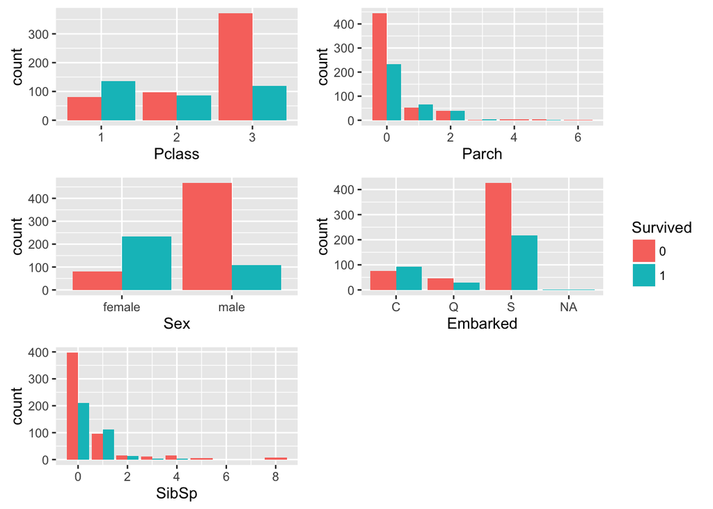

```r
get_legend<-function(myggplot){
  tmp <- ggplot_gtable(ggplot_build(myggplot))
  leg <- which(sapply(tmp$grobs, function(x) x$name) == "guide-box")
  legend <- tmp$grobs[[leg]]
  return(legend)
}
p <- lapply(X = c('Pclass','Sex','SibSp','Parch','Embarked'),
            FUN = function(x) ggplot(data = train.raw)+
                aes_string(x=x,fill='Survived')+
                geom_bar(position="dodge")+
                theme(legend.position="none"))
legend <- get_legend(ggplot(data = train.raw,aes(x=Pclass,fill=Survived))+geom_bar())
grid.arrange(p[[1]],p[[2]],p[[3]],p[[4]],p[[5]],legend,layout_matrix = cbind(c(1,2,3),c(4,5,NA),c(6,6,6)),widths=c(3,3,1))
```

```r
round(prop.table(table(train.raw$Embarked,train.raw$Pclass),margin = 2),2)
```

```
##
##        1    2    3
##   C 0.40 0.09 0.13
##   Q 0.01 0.02 0.15
##   S 0.59 0.89 0.72
```

### Multivariate Analyses

Grouped boxplots are a common method of comparing distributions grouped by categorical variables. I find [beanplots](https://cran.r-project.org/web/packages/beanplot/beanplot.pdf) to be excellent complementary plots to boxplots (and in some cases, even better). They’re a bit tricky to read at first - since they are so underutilized - but just through one plot, a wealth of information can be extracted.[^3]

Here is a comparison of the same information between a boxplot and a beanplot. What can we infer from the bean plot better?

1. The beanplot allows us to visualize the density function of the parameter, in this case: Age. Furthermore, the length of each beanline is cumulative to the number of datapoints that exist. Rightaway, we can tell that Pclass=3 has the most data in the set, with sparser data at Pclass=1.
2. The mean values for 1st class is higher than that for 2nd and 3rd class. The distributions of deceased and survived for 1st class are fairly similar.
3. For 2nd and 3rd class, the survived data shows a bimodal distribution. Bumps at the 0-10 age show that children were evacuated first. This is also the reason the mean values for survived is lower.
4. For 2nd and 3rd class, the deceased data shows a fairly normal distribution.
5. The individual measurements (represented by black lines) represent each observation and help identify outliers much more easily than a boxplot does.

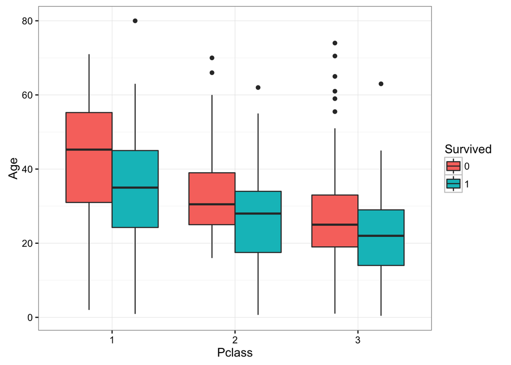

```r
ggplot(train.raw,aes(y=Age,x=Pclass))+geom_boxplot(aes(by=Survived,fill=Survived))+theme_bw()
```

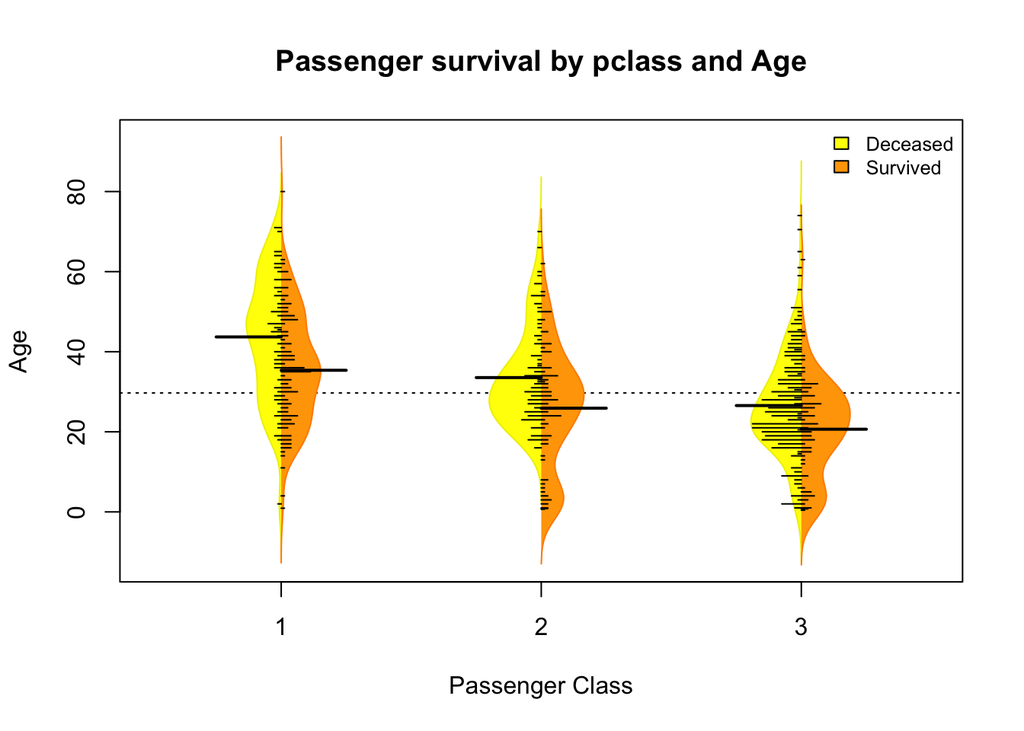

```r
beanplot(Age~Survived*Pclass,side='b',train.raw,col=list('yellow','orange'),
         border = c('yellow2','darkorange'),ll = 0.05,boxwex = .5,
         main='Passenger survival by pclass and Age',xlab='Passenger Class',ylab='Age')
legend('topright', fill = c('yellow','orange'), legend = c("Deceased", "Survived"),bty = 'n',cex = .8)
```

A look into the `SibSp` and `Parch` variables shows something interesting. There are three regions one can identify:

- The probability of survival is minimal for number of parents/children aboard > 3.
- The probability of survival is minimal for number of siblings/spouses aboard > 3.
- For `SibSp`<=3 and `Parch`<=3, there are better chances for survival.

The grouping by `Pclass` reveals that all the large families were 3rd class travelers. Worse access to help… lowest chance for survival.

These could be simple rules either hard coded during model building: something along the lines of: *IF (SibSp>3 OR Parch >3) THEN prediction = 0*, or some derived variables can be created.

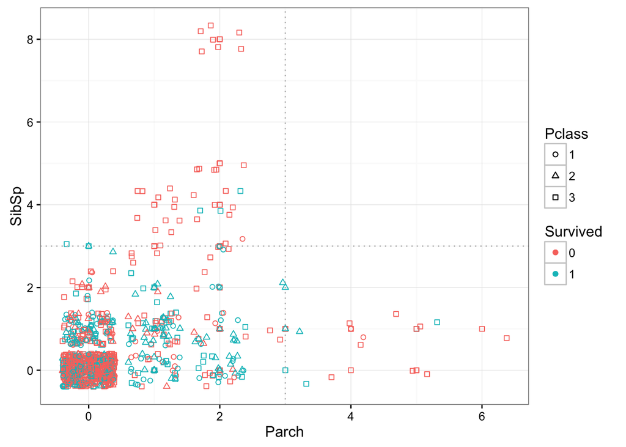

```r
ggplot(train.raw,aes(y=SibSp,x=Parch))+
    geom_point(aes(color=Survived,shape=Pclass))+
    geom_jitter(aes(color=Survived,shape=Pclass))+
    theme_bw()+
    scale_shape(solid=F)+
    geom_vline(xintercept = 3,color='gray',lty=3)+
    geom_hline(yintercept = 3,color='gray',lty=3)
```

# Data Preparation

## Missing Values Imputation

Starting with the easier one first:

**Embarked**: The largest portion of the passengers embared at Southhampton. I’m replacing the NAs with the same. First, I create a new imputed training dataset.

```r
summary(train.raw$Embarked)
```

```
##    C    Q    S NA's
##  168   77  644    2
```

```r
train.imp <- train.raw
train.imp$Embarked[is.na(train.imp$Embarked)]='S'
summary(train.imp$Embarked)
```

```
##   C   Q   S
## 168  77 646
```

**Age**:

Using the names to extract titles…

```r
train.raw$title <- str_extract(pattern = '[a-zA-Z]+(?=\\.)',string = train.raw$Name)
train.raw$title <- as.factor(train.raw$title)

train.raw %>% na.omit() %>% group_by(title) %>% dplyr::summarise(Count=n(),Avg=round(mean(Age),0)) %>% arrange(-Avg)
```

```
## # A tibble: 13 × 3
##       title Count   Avg
##      <fctr> <int> <dbl>
## 1      Capt     1    70
## 2       Col     1    56
## 3       Sir     1    49
## 4      Lady     1    48
## 5     Major     2    48
## 6        Dr     3    42
## 7        Mr    81    40
## 8       Mrs    38    38
## 9  Countess     1    33
## 10     Miss    44    28
## 11     Mlle     2    24
## 12      Mme     1    24
## 13   Master     7     4
```

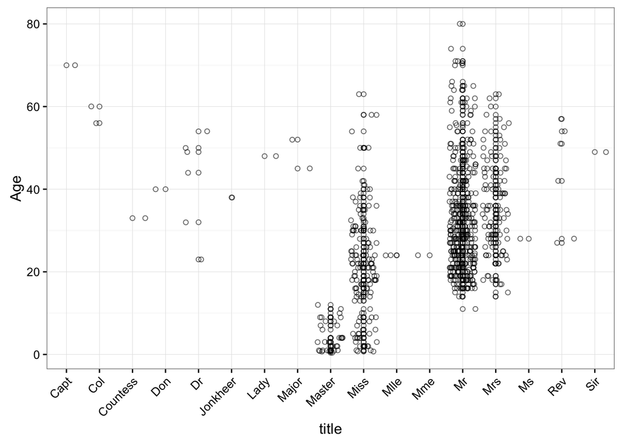

```r
ggplot(train.raw,aes(x=title,y=Age))+
    geom_point(shape=21,alpha=.6)+
    geom_jitter(shape=21,alpha=.6)+
    theme_bw()+
    theme(axis.text.x = element_text(angle = 45, hjust = 1),legend.position="none")
```

Grouping similar titles together…

```r
train.imp <- train.raw
train.imp$title <- as.character(train.imp$title)
train.imp$title[train.imp$title %in% c('Capt','Col')] <- 'Senior'
train.imp$title[train.imp$title %in% c('Don','Dr','Major','Mr','Rev','Sir','Jonkheer')] <- 'Mr'
train.imp$title[train.imp$title %in% c('Countess','Lady','Mrs','Mlle','Mme')] <- 'Mrs'
train.imp$title[train.imp$title %in% c('Ms')] <- 'Miss'
train.imp$title <- as.factor(train.imp$title)
train.imp$Name <- NULL
table(train.imp$title)
```

```
##
## Master   Miss     Mr    Mrs Senior
##     40    183    535    130      3
```

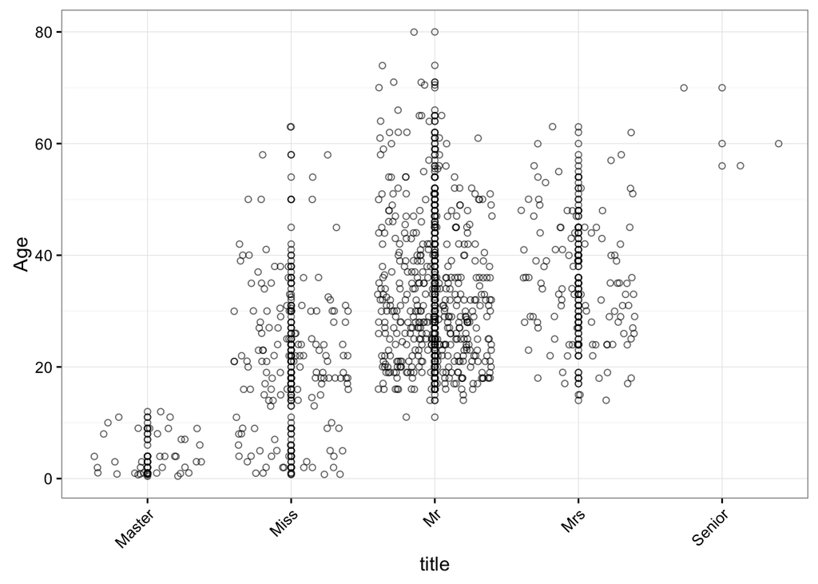

```r
ggplot(train.imp,aes(x=title,y=Age))+
    geom_point(shape=21,alpha=.6)+
    geom_jitter(shape=21,alpha=.6)+
    theme_bw()+
    theme(axis.text.x = element_text(angle = 45, hjust = 1),legend.position="none")
```

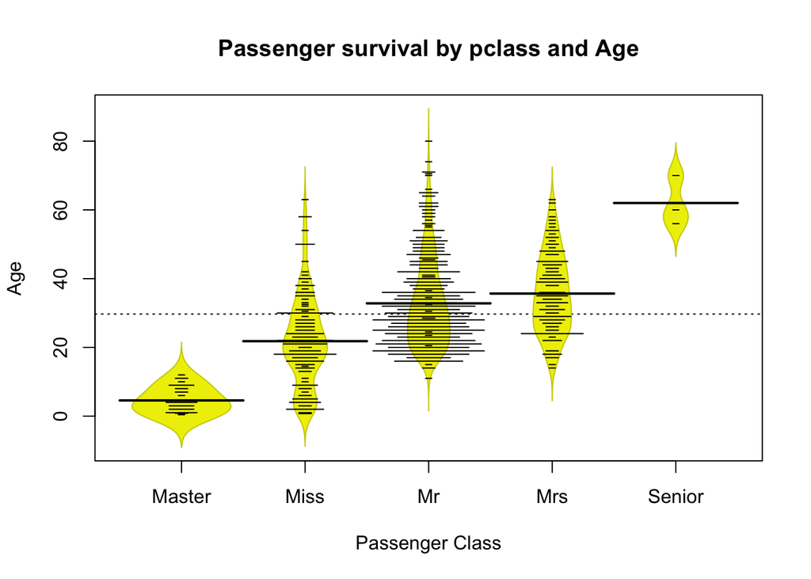

```r
beanplot(Age~title,train.imp,col='yellow2', border = 'yellow3',ll = 0.05,boxwex = 1,log = '',
         main='Passenger survival by pclass and Age',xlab='Passenger Class',ylab='Age')
```

```r
train.imp %>% group_by(title) %>% summarise(median(Age,na.rm = T))
```

```
## # A tibble: 5 × 2
##    title `median(Age, na.rm = T)`
##   <fctr>                    <dbl>
## 1 Master                      3.5
## 2   Miss                     21.0
## 3     Mr                     30.0
## 4    Mrs                     35.0
## 5 Senior                     60.0
```

age is imputed here…

```r
age.predictors <- train.imp %>% select(-Survived,-Cabin,-Ticket)
age.predictors <- age.predictors[complete.cases(age.predictors),]
ctrl <- trainControl(method = "repeatedcv", repeats = 5)
rpartFit <- train(Age~.,data=age.predictors,method='rpart2',trControl = ctrl,maxdepth=10)
```

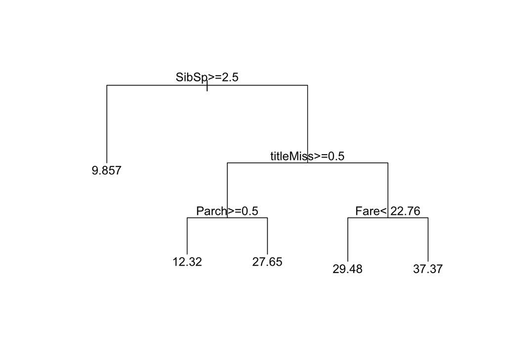

```r
plot(rpartFit$finalModel,margin = .1)
text(rpartFit$finalModel)
```

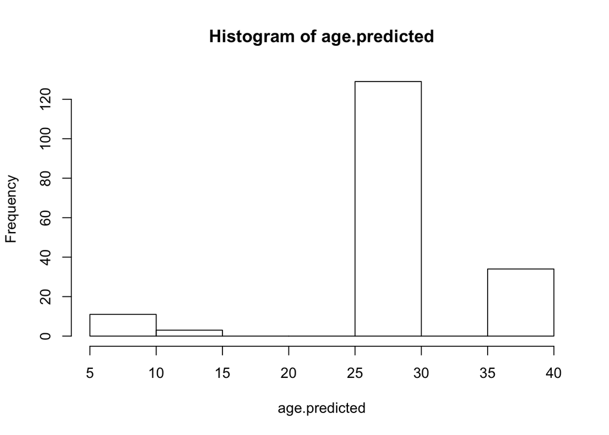

```r
missing.age <- train.imp %>% select(-Survived,-Cabin,-Ticket) %>% filter(is.na(Age))
age.predicted <- predict(rpartFit, newdata = missing.age)
hist(age.predicted)
```

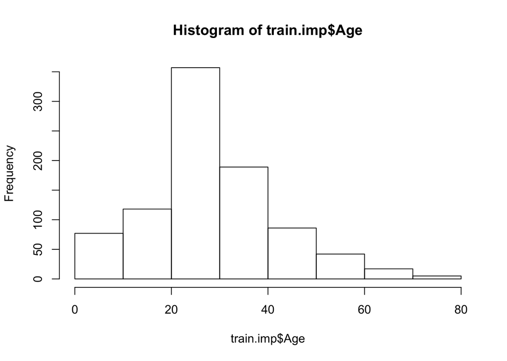

```r
age.predicted[missing.age$title=='Master'] <- 3.5
train.imp$Age[is.na(train.imp$Age)] <- age.predicted
hist(train.imp$Age)
```

## Derived Variables

```r
train.imp$child <- 0
train.imp$child[train.imp$Age<18] <- 1
train.imp$child <- as.factor(train.imp$child)
```

## Winzoring Variables

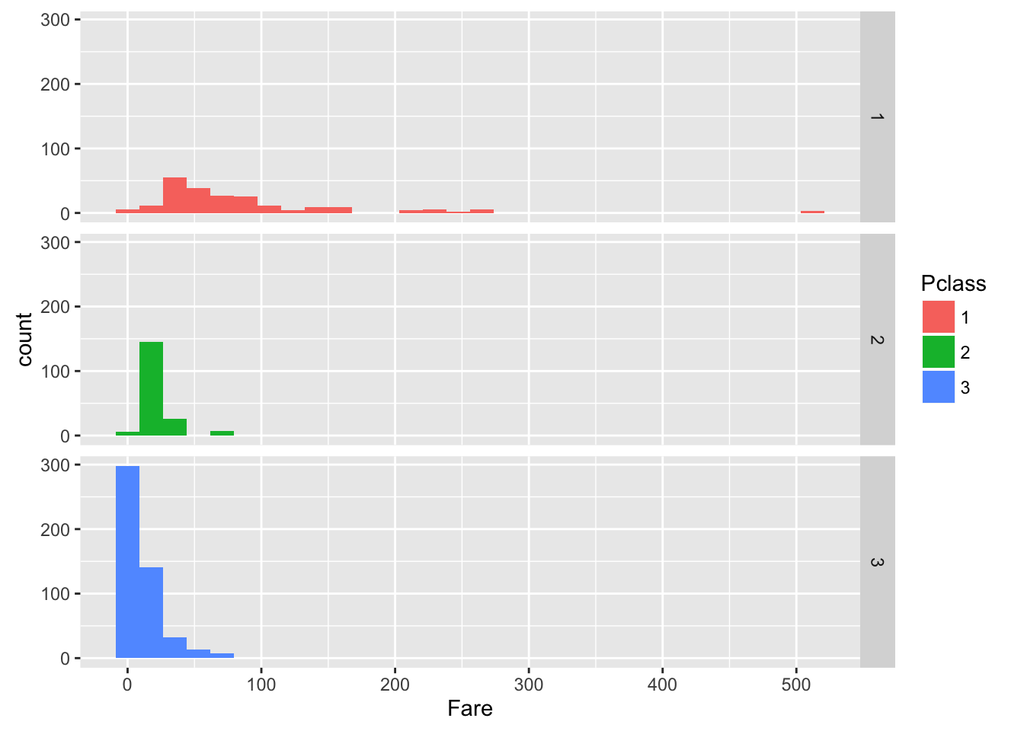

```r
ggplot(train.imp,aes(x=Fare,fill=Pclass))+geom_histogram()+facet_grid(Pclass~.)
```

```r
quantile(train.imp$Fare[train.imp$Pclass==1],probs = c(.1,.25,.5,.75,.90))
```

```
##       10%       25%       50%       75%       90%
##  26.55000  30.92395  60.28750  93.50000 159.16460
```

```r
train.imp$Fare[train.imp$Fare>159] <- 159
```

## Transformations

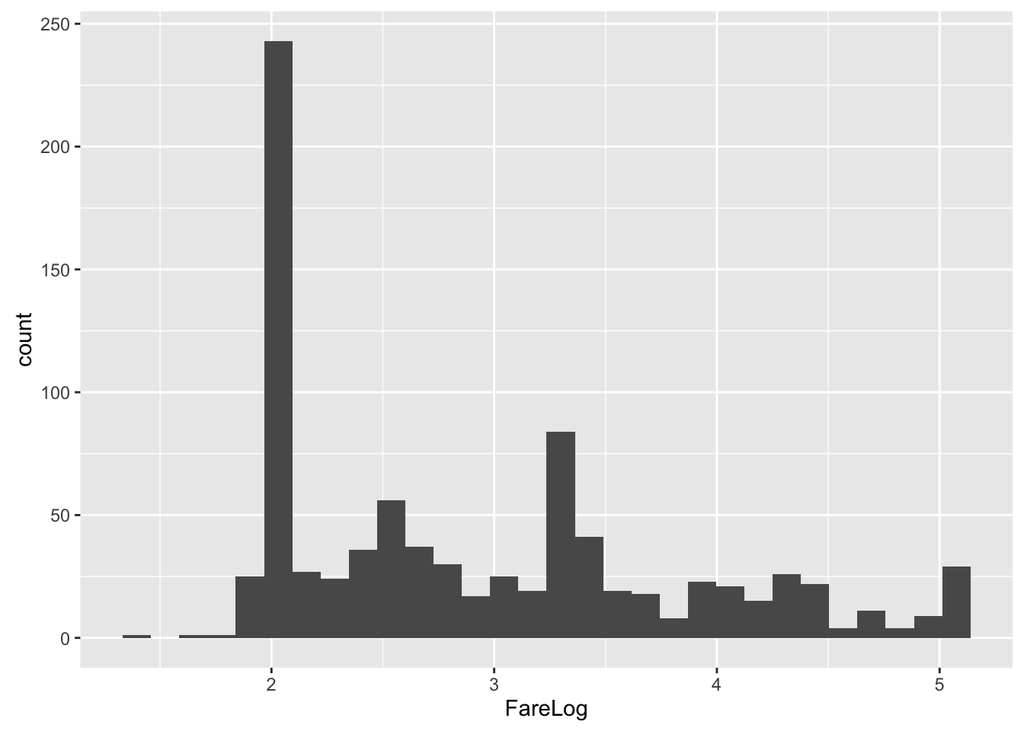

```r
train.imp$FareLog <- log(train.imp$Fare)
ggplot(train.imp,aes(FareLog))+geom_histogram()
```